# M3 PushNotifications and Recommender systems

# Introduction to R

```r
print("Marfeel rocks!")
```

```
[1] "Marfeel rocks!"
```

Lets create a string to personalize the message

```r
name <- "Marfeelers"
personalizedMessage <- paste0(name, " rock!!!")
print(personalizedMessage)
```

```
[1] "Marfeelers rock!!!"
```

Lets create some messages in bulck

```r
nameList <- c( "I", "You", "We", "They", "Marfeelers")
for (name in nameList){
  print(paste0(name, " rock!!!"))
}
```

```
[1] "I rock!!!"
[1] "You rock!!!"
[1] "We rock!!!"
[1] "They rock!!!"
[1] "Marfeelers rock!!!"
```

Lets vectorize this

```r
nameList <- c( "I", "You", "We", "They", "Marfeelers")
print(paste0(nameList, " rock!!!"))
```

```
[1] "I rock!!!"          "You rock!!!"        "We rock!!!"         "They rock!!!"       "Marfeelers rock!!!"
```

## Data Frame and rock and roll

Data frame is R’s work horse. A data frame is a matrix-like data structure. Each row is an observation, and each column is a variable of the observations. Columns may have different data types.

We start by loading some data

```r
#install.packages("readr")
library(readr)
myData <- read_csv("./resources/sampleData1.csv")
```

Lets take a look at the first observations of the data

```r
head(myData)
```

| page | channel | exits | pageViews |
| --- | --- | --- | --- |
| / | Organic Search | 79740 | 179836 |
| / | Direct | 48487 | 130846 |
| /2018/06/fornite-android-lanzamiento | Organic Search | 41263 | 55019 |
| / | (Other) | 33535 | 113658 |
| /2018/07/7-trucos-fortnite | Organic Search | 21701 | 31390 |
| / | Referral | 18338 | 37705 |

This is the dimensions of the data frame: rows and columns

```r
dim(myData)
```

```
[1] 2501    4
```

Plots some summary statistics

```r
summary(myData)
```

```
     page             channel              exits           pageViews
 Length:2501        Length:2501        Min.   :     40   Min.   :     40
 Class :character   Class :character   1st Qu.:     57   1st Qu.:     92
 Mode  :character   Mode  :character   Median :    109   Median :    183
                                       Mean   :   1144   Mean   :   2309
                                       3rd Qu.:    320   3rd Qu.:    686
                                       Max.   :1481609   Max.   :3034065
```

Some numbers are very high. Why?

```r
View(myData)
```

Lets remove the NA

```r
myData <- na.omit(myData)
dim(myData)
```

```
[1] 2500    4
```

```r
summary(myData)
```

```
     page             channel              exits           pageViews
 Length:2500        Length:2500        Min.   :   40.0   Min.   :    40
 Class :character   Class :character   1st Qu.:   57.0   1st Qu.:    92
 Mode  :character   Mode  :character   Median :  109.0   Median :   183
                                       Mean   :  552.2   Mean   :  1096
                                       3rd Qu.:  320.0   3rd Qu.:   686
                                       Max.   :79740.0   Max.   :179836
```

Note that “page” and “channel” are of class character. Lets transform them as factors. Factor is like an “enum” in Java, is a variable that can have a limited amount of values.

```r
myData$page <- as.factor(myData$page)
myData$channel <- as.factor(myData$channel)
summary(myData)
```

```
                                             page                channel         exits           pageViews
 /                                             :   4   Direct        : 552   Min.   :   40.0   Min.   :    40
 /2018/03/tiendas-online-fiables               :   4   Organic Search:1536   1st Qu.:   57.0   1st Qu.:    92
 /2018/06/fornite-android-lanzamiento          :   4   (Other)       : 248   Median :  109.0   Median :   183
 /2018/06/ok-google-comandos-activar-desactivar:   4   Referral      : 164   Mean   :  552.2   Mean   :  1096
 /2018/07/16-gb-ram-samsung                    :   4                         3rd Qu.:  320.0   3rd Qu.:   686
 /2018/07/7-trucos-fortnite                    :   4                         Max.   :79740.0   Max.   :179836
 (Other)                                       :2476
```

Lets check how many different pages and channels ther are

```r
nlevels(myData$page)
```

```
[1] 1646
```

```r
nlevels(myData$channel)
```

```
[1] 4
```

## Operate with data frame and dplyr

Lets create a new column in the data frame that is the % of exits in for each article and channel

```r
myData$exitsPct <- myData$exits / myData$pageViews
summary(myData)
```

```
                                             page                channel         exits           pageViews         exitsPct
 /                                             :   4   Direct        : 552   Min.   :   40.0   Min.   :    40   Min.   :0.0383
 /2018/03/tiendas-online-fiables               :   4   Organic Search:1536   1st Qu.:   57.0   1st Qu.:    92   1st Qu.:0.5246
 /2018/06/fornite-android-lanzamiento          :   4   (Other)       : 248   Median :  109.0   Median :   183   Median :0.6690
 /2018/06/ok-google-comandos-activar-desactivar:   4   Referral      : 164   Mean   :  552.2   Mean   :  1096   Mean   :0.6372
 /2018/07/16-gb-ram-samsung                    :   4                         3rd Qu.:  320.0   3rd Qu.:   686   3rd Qu.:0.7843
 /2018/07/7-trucos-fortnite                    :   4                         Max.   :79740.0   Max.   :179836   Max.   :1.0000
 (Other)                                       :2476
```

Lets visualize the histogram of existsPct

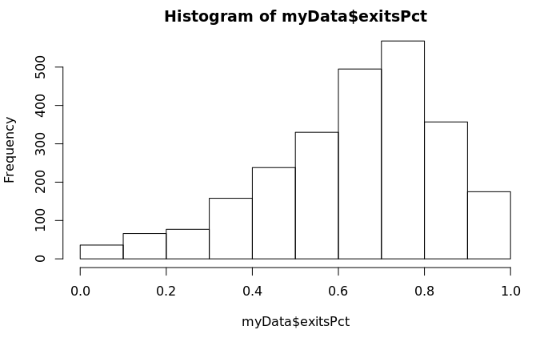

```r
hist(myData$exitsPct)
```

Lets remove the column that we just created.

```r
myData$exitsPct <- NULL
```

Lets check if the exitPct is very different from channel to channel

```r
library(plyr)
library(dplyr)
exitPctByChannel <- myData %>%
  mutate(exitsPct = exits / pageViews) %>%
  group_by(channel) %>%
  dplyr::summarize(exitsPct = mean(exitsPct))
exitPctByChannel
```

| channel | exitsPct |
| --- | --- |
| Direct | 0.5694453 |
| Organic Search | 0.7049162 |
| (Other) | 0.4382974 |
| Referral | 0.5319443 |

With mutate we create a new column, with group_by, we group the rows, most of the subsequent operations are done by group. Summarize computes summary statistics from each group and retruns a single row for each group.

Note that, the mean exitPct is not properly calculated. All articles have the same weight. Example, if we have two articles one with 100 visits and an exit rate of 25%, and another article with 100M visits and an exit rate of 75%, ther exit rate will be 50% this is not right.

```r
exitPctByChannelProperlyComputed <- myData %>%
  mutate(exitsPct = exits / pageViews) %>%
  group_by(channel) %>%
  dplyr::summarize(exitsPctCorrect = weighted.mean(exitsPct, pageViews), totalAmountOfPageViews = sum(pageViews), sdOfPageViews = sd(pageViews)) %>%
  arrange(exitsPctCorrect)
exitPctByChannelProperlyComputed
```

| channel | exitsPctCorrect | totalAmountOfPageViews | sdOfPageViews |
| --- | --- | --- | --- |
| (Other) | 0.4093919 | 614807 | 7755.806 |
| Direct | 0.4732025 | 739491 | 6127.103 |
| Organic Search | 0.5596651 | 1134952 | 5102.108 |
| Referral | 0.5723059 | 251086 | 3260.267 |

sum adds all elements in that column in that group. sd computes the standard deviation. arrange orders the dataframe rows in ascending order of exitsPctCorrect.

```r
?sd
```

## Exercise 1

Compute the exitsPctCorrect (that is the percentage of page views that are exits) for each channel without using the “weigthed.sum” function. Use “sum”" only.

```r
#your code goes here
```

# Recommender system

## Data exploration

We start by loading the data that is located in the /resources folder

```r
dataRecom <- read_csv("./resources/dataRecommender.csv")
dim(dataRecom)
```

```
[1] 809633      3
```

Lets explore the data

```r
head(dataRecom)
```

| location | userId | date |
| --- | --- | --- |
| https://eresmama.com/ | d735cb30-a85a-11e8-9d6d-2d2d461d3ee2 | 2018-08-25 |
| https://eresmama.com/ | 1240f200-a8a0-11e8-bb4e-a9a596ea7fa6 | 2018-08-25 |
| https://eresmama.com/ | af3a521c-dbca-4362-97b4-798a456db1c9 | 2018-08-25 |
| https://eresmama.com/ | f2806f30-a855-11e8-85bf-4dd0f962624c | 2018-08-25 |
| https://eresmama.com/ | 208534a4-336e-4169-bfdd-11766e65c89a | 2018-08-25 |
| https://eresmama.com/ | 84230a50-8d27-11e8-a415-55f4acad626e | 2018-08-25 |

The date column we wont use it, the location eresmama we don’t want it. We wont recommend the home XD.

```r
dataRecom <- dataRecom %>% select(-date) %>% filter(!(location %in% "https://eresmama.com/"))
```

[output not shown]

Usually rating matrix is very sparse (most of its values are zero). Lets investigate how is this matrix. For that we will crate a function. We don’t have ratings, we only have interactions… this is called binary implicit feedback.

```r
printSparsityMetrics <- function(data){

  amountItem <- as.numeric(nlevels(as.factor(data$location)))
  amountOfUsers <- as.numeric(nlevels(as.factor(data$userId)))
  amountOfelementsInMatrix <- amountOfUsers*amountItem

  sparcity <- 100 * (1 - nrow(data) / (amountOfelementsInMatrix))

  print(paste0(" amount of items: ", amountItem, " of users: ", amountOfUsers, " sparsiy: ", sparcity, " amount of elements: ",  amountOfelementsInMatrix))

  ratingsByUser <- data %>% group_by(userId) %>% dplyr::summarize(num = n())

  print("--- users ---")
  print(summary(ratingsByUser$num))

  ratingsByItem <- data %>% group_by(location) %>% dplyr::summarize(num = n())

  print("--- items ---")
  print(summary(ratingsByItem$num))
}
```

```r
printSparsityMetrics(dataRecom)
```

```
[1] " amount of items: 9321 of users: 367249 sparsiy: 99.9820099916575 amount of elements: 3423127929"
[1] "--- users ---"
   Min. 1st Qu.  Median    Mean 3rd Qu.    Max.
  1.000   1.000   1.000   1.677   2.000 584.000
[1] "--- items ---"
    Min.  1st Qu.   Median     Mean  3rd Qu.     Max.
    1.00     1.00     4.00    66.07    16.00 15640.00
```

We wont be dealing with users that connect only sporadically, neither with articles that have very few visits. Lets clean this up.

```r
minNumTimesArticleRated <- 1000
minNumUserRatins <- 3
dataRecomClean <- dataRecom %>%
  group_by(location) %>%
  dplyr::mutate(numTimesRated = n()) %>%
  filter(numTimesRated > minNumTimesArticleRated) %>%
  group_by(userId) %>%
  dplyr::mutate(numItemRatings = n() )%>%
  filter(numItemRatings > minNumUserRatins)
```

```r
printSparsityMetrics(dataRecomClean)
```

```
[1] " amount of items: 124 of users: 8113 sparsiy: 95.698262048564 amount of elements: 1006012"
[1] "--- users ---"
   Min. 1st Qu.  Median    Mean 3rd Qu.    Max.
  4.000   4.000   5.000   5.334   6.000  52.000
[1] "--- items ---"
   Min. 1st Qu.  Median    Mean 3rd Qu.    Max.
   22.0   170.8   328.0   349.0   480.5  1271.0
```

Lets remove from the workspace the other dataframe.

```r
rm(dataRecom)
```

## item similarity

We will use the recommenderLab package. It provides a nice bunch of functions and objects to work in recommenders. Moreover we have to use a specific class, that is optimized to deal with sparse matrices.

```r
library(recommenderlab)
dataRecomCleanWithFactors <- data.frame(user = as.factor(dataRecomClean$userId), items = as.factor(dataRecomClean$location))
dataRating <- as(dataRecomCleanWithFactors, "binaryRatingMatrix")
```

```r
getSimilarArticles <- function(articleName, distanceMatrix, numberOfSimilarArticles = 1){

  if(articleName %in% colnames(distanceMatrix)){
    articleDistance <- distanceMatrix[articleName , ]
    similarArticles <- names(sort(articleDistance, decreasing = TRUE)[1:numberOfSimilarArticles])

  }else{
    return(NULL)
  }
}
```

```r
article <- "https://eresmama.com/toxoplasmosis-y-alimentos-prohibidos-en-el-embarazo/"
aa<-getSimilarArticles(article, similarityData, 4)
```

## First recommender

### How to evaluate recommenders

A typical form is to use the “given” method and some sort of data-splitting (crossvalidation, train-test split, or bootstrap). Rememver that we are only tring to predict interaction, not ranking. We would like to recommend items that the users are likely to interact with.

For example given-10 and a data split of 90% works as follow. In the training: For 90% of the users we use all the data, for the remaining 10%, we use only 10 items in the training. The rest of the items of those users are keep apart.

In evaluation: We use only the 10% of users, we ask the recommender to recommend some items for those users. Then we compare the items recommended with the list of items that were keept apart in the training phase.

Note that the recommender can make more than one recommendation per user.

Precision: #topK and relevant / #top k

Recall: #top k and relevant / #relevant recommendations

Relevant recommendations are those that are keep apart in the training phase. Top K is the list of items recommended.

### Simple example

```r
e <- evaluationScheme(dataRating, method = "split", train = 0.8, given = -1)
```

```r
model <- Recommender(data = getData(e, "train"), method = "IBCF")
recommendations <- predict(model, newdata = getData(e, "unknown"), n = 10, type="topNList")
```

lets look at some recommendations

```r
recommendations
```

[output not shown]

```r
calcPredictionAccuracy(recommendations, getData(e, "known"), given = -1)
```

## Comparing recommenders

Lets see whcih recommenders we have

```r
recommenderRegistry$get_entries()
```

Lets compare some of them

```r
algorithms <- list(
  RANDOM = list(name = "RANDOM", param = NULL),
  POPULAR = list(name = "POPULAR", param = NULL),
  IBCF20 = list(name = "IBCF", param = list(k = 20)),
  IBCF40 = list(name = "IBCF", param = list(k = 40)),
  IBCF60 = list(name = "IBCF", param = list(k = 60)),
  UBCF20 = list(name = "UBCF", param = list(nn = 20)),
  UBCF60 = list(name = "UBCF", param = list(nn = 60)),
  UBCF90 = list(name = "UBCF", param = list(nn = 90)),
  ALS10 = list(name = "ALS_implicit", param=list(n_factors = 10)),
  ALS5 = list(name = "ALS_implicit", param=list(n_factors = 5)),
  ALS20 = list(name = "ALS_implicit", param=list(n_factors = 20))
)
results <- evaluate(e, algorithms, type = "topNList", n = c(1,2,3,4,5))
```

```
RANDOM run fold/sample [model time/prediction time]
     1  [0.001sec/0.811sec]
POPULAR run fold/sample [model time/prediction time]
     1  [0.014sec/11.487sec]
IBCF run fold/sample [model time/prediction time]
     1  [0.355sec/0.598sec]
IBCF run fold/sample [model time/prediction time]
     1  [0.35sec/0.699sec]
IBCF run fold/sample [model time/prediction time]
     1  [0.354sec/0.716sec]
UBCF run fold/sample [model time/prediction time]
     1  [0sec/32.566sec]
UBCF run fold/sample [model time/prediction time]
     1  [0sec/32.285sec]
UBCF run fold/sample [model time/prediction time]
     1  [0sec/31.977sec]
ALS_implicit run fold/sample [model time/prediction time]
     1  [0.098sec/496.338sec]
ALS_implicit run fold/sample [model time/prediction time]
     1  [0.001sec/472.545sec]
ALS_implicit run fold/sample [model time/prediction time]
     1  [0sec/478.097sec]
```

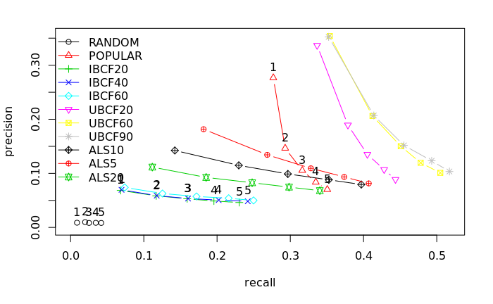

```r
plot(results, "prec/rec", annotate=c(1,2,3,4), legend="topleft")
```